# TP 1: Introduction à la cartographie

## Contexte

On a des observations $z(\mathbf{x}_1),\dots, z(\mathbf{x}_n)$ d'un phénomène en des points $\left(\mathbf{x}_i\right)_{i=1}^n$ d'un domaine spatial $\mathcal{D} \subset \mathbb{R}^d$, et on veut prédire la valeur de $z(\mathbf{x}_0)$ en un nouveau point $\mathbf{x}_0$ pour lequel on n'a pas d'observations

Les méthodes employées ici sont des prédicteurs linéaires :

$$\hat{z}(\mathbf{x}_0) = \sum_{i=1}^{n} \lambda_i(\mathbf{x}_0)z(\mathbf{x}_i)$$

## Cadre du TP

Ici, dans le cadre de ce TP, les $n$ observations sont placées dans un fichier csv. On va ensuite vouloir prédire le phénomène dans l'ensemble du domaine, en des points stockées dans un second fichier csv. Comme l'objectif ici est d'explorer différentes approches, on a en réalité connaissance des vraies valeurs du phénomène dans l'ensemble du domaine, et on va notamment pouvoir visualiser les vraies cartes et les comparer à nos prédictions.

### On importe les libraries nécessaires

Vous devrez probablement télécharger certaines librairies. Exemple : pip install pandas

```python
import pandas as pd
import matplotlib.pyplot as plt
import matplotlib.colors as colors
import numpy as np
import cartopy.crs as ccrs
import cartopy.feature as cfeature
from scipy.optimize import minimize
```

La cellule ci-dessous ne concerne que les élèves sur google colab

!git clone https://github.com/CharlieSire/tp1_geostatistics.git repo_tmp !cp -r repo_tmp/* . !rm -rf repo_tmp

## 2 fonctions importantes :

- La fonction "plot_data" permet d'afficher les cartes à partir d'un tableau numpy.array. La premier colonne du tableau correspond à l'abscisse, la deuxième à l'ordonnée, et la troisième à la valeur du phénomène. Eventuellement, un tableau numpy.array contenant les points d'observations peut être renseigné sous l'argument "df_obs", afin de visualiser les localisations de ces points. Les paramètres vmin et vmax permettent de fixer éventuellement des bornes pour l'échelle de couleur utilisée. Il sera vivement conseillé d'utiliser toujours l'échelle de couleur associée aux vraies valeurs du phénomène.
- La fonction "dist_point_obs" prend en argument un point x (donc un vecteur en 2 dimensions), un tableau "df_obs" contenant les points d'observations, et retourne un vecteur contenant les distances euclidiennes entre le point x et chaque point de df_obs.

```python
def plot_data(df, df_obs = None, vmin = None, vmax = None, titre = ""):
    if vmin is None: vmin = min(df[:,2])
    if vmax is None: vmax = max(df[:,2])
    #plt.figure(figsize=(6.2,5))
    fig, ax = plt.subplots()
    im = ax.tricontourf(
    df[:,0], df[:,1], df[:,2],
    levels=100, cmap="magma")
    fig.colorbar(plt.cm.ScalarMappable(norm=colors.Normalize(vmin, vmax), cmap='magma'),ax=ax, orientation='vertical', label='')
    if df_obs is not None: plt.scatter(df_obs[:,0], df_obs[:,1], c='white', edgecolor='black', s=20, label='Observations')
    ax.set_title(titre)

    plt.show()

def dist_point_obs(x, df_obs):
    dists = np.sqrt(np.sum((df_obs[:, :2] - x)**2, axis=1))
    return(dists)
```

# Partie I : Données synthétiques

Ici, on utiliser les observations stockées dans le tableau "df_obs_1.csv", et on va vouloir prédire le phénomène en tous les points du tableau "data_1.csv". Pour ces 2 tableaux, les 2 premières colonnes correspondent aux coordonnées spatiales, et la 3e à la valeur du phénomène.

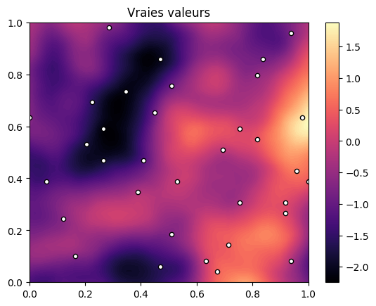

```python
df = pd.read_csv("data/data_1.csv").values #les données à prédire
df_obs = pd.read_csv("data/df_obs_1.csv").values #les données d'observation
plot_data(df, df_obs, titre = "Vraies valeurs") #afficher les données à predire
```

## I.1 Nearest neighbor

Une première méthode possible est simplement d'attribuer à $\hat{z}(\mathbf{x}_0)$ la valeur de son plus proche voisin parmi les observations $\left(z(\mathbf{x}_i)\right)_{i=1}^{n}.$

Formellement, cela revient à $$\hat{z}(\mathbf{x}_0) = z(\mathbf{x}_i) \text{ où } i=\underset{j = 1,\dots,n}{\text{arg}\min}\lVert \mathbf{x}_{j}-\mathbf{x}_0 \rVert$$

On a bien un prédicteur linéaire $\hat{z}(\mathbf{x}_0) = \sum_{i=1}^{n} \lambda_i(\mathbf{x}_0)z(\mathbf{x}_i)$ avec $$\lambda_i(\mathbf{x}_0) = \mathbb{1}_{\lVert \mathbf{x}_i - \mathbf{x}_0 \rVert = \underset{j = 1,\dots,n}{\min} \lVert \mathbf{x}_j - \mathbf{x}_0 \rVert } $$

#### Question 1 : Coder la fonction en complétant le code ci-dessous

```python
def nearest_neighbor(x0, df_obs):
    dists = dist_point_obs(x0, df_obs) #calculer la distance entre x0 et les points de df_obs
    closest_idx = np.argmin(dists) #Selectionner le point le plus proche
    return(df_obs[closest_idx, 2]) #retourner sa valeur
```

On va appliquer la fonction à chaque point de notre domaine, et stocker la prédiction dans un tableau df_nn.

#### Question 2: Observer la prédiction en utilisant la fonction plot_data. Veuillez bien à renseigner vmin et vmax pour avoir la même échelle de couleur que pour la carte des vraies valeurs.

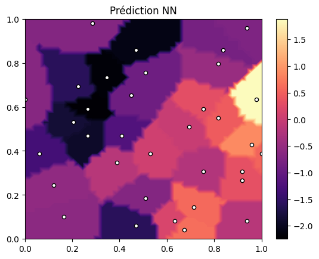

```python
pred_nn = np.apply_along_axis(lambda x:nearest_neighbor(x, df_obs), 1, df[:,:2]) #appliquer la fonction nearest neighbor à chaque point de df
df_nn =  np.column_stack((df[:,:2], pred_nn)) #créer un tableau avec les coordonnées des points et la valeur prédite

plot_data(df_nn, df_obs, vmin = min(df[:,2]), vmax = max(df[:,2]), titre = "Prédiction NN") #Afficher la carte prédite
```

## I.2 K Nearest neighbors

Afin d'obtenir des prédictions plus lisses, une méthode possible est d'attribuer à $\hat{z}(\mathbf{x}_0)$ la valeur moyenne de ses k plus proches voisins parmi les observations $\left(z(\mathbf{x}_i)\right)_{i=1}^{n}.$

On a encore un prédicteur linéaire $\hat{z}(\mathbf{x}_0) = \sum_{i=1}^{n} \lambda_i(\mathbf{x}_0)z(\mathbf{x}_i)$ avec $$\lambda_i(\mathbf{x}_0) = \frac{1}{K}\mathbb{1}_{\mathbf{x}_i \in V_K(\mathbf{x}_0)} \text{ où } V_K(\mathbf{x}_0) \text{ est l'ensemble des }K \text{ plus proches voisins de }\mathbf{x}_0 $$ On peut écrire $$V_K(\mathbf{x}_0) = \left\{i \in 1,\dots,n, \text{card}\{j \in 1,\dots,n, \lVert \mathbf{x}_j -\mathbf{x}_0\rVert \leq \lVert \mathbf{x}_i -\mathbf{x}_0\rVert\} = K\right\}$$

#### Question 3 : Coder la fonction en complétant le code ci-dessous

```python
def k_nearest_neighbor(x0,k, df_obs):
    dists = dist_point_obs(x0, df_obs) #calculer la distance entre x0 et les points de df_obs
    closest_idx = np.argsort(dists)[:k] #Trier ces distances et sélectionner les k points les plus proches
    return(np.mean(df_obs[closest_idx, 2])) #retourner la moyennes des valeurs en ces points
```

#### Question 4 : Calculer la prédiction en chaque point du domaine (i.e. chaque point du tableau df) avec $K=3$, et stocker les résultats dans un tableau "df_knn".Observer la prédiction en utilisant la fonction plot_data

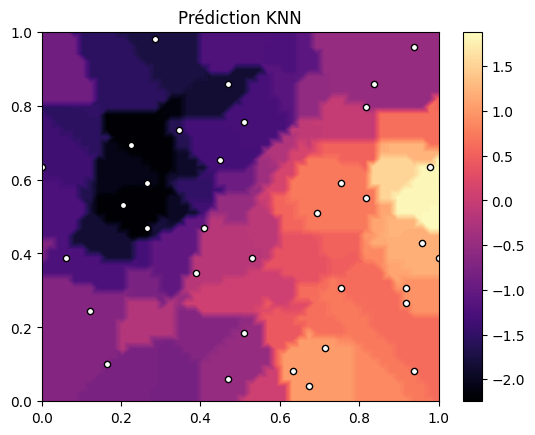

```python
pred_knn = np.apply_along_axis(lambda point: k_nearest_neighbor(point, 3, df_obs), 1, df[:,:2]) #appliquer la fonction KNN à chaque point de df
df_knn =  np.column_stack((df[:,:2], pred_knn)) #créer un tableau avec les coordonnées des points et la valeur prédite

plot_data(df_knn, df_obs, vmin = min(df[:,2]), vmax = max(df[:,2]), titre = "Prédiction KNN") #afficher la carte prédite
```

## I.3 Inverse distance

On peut également obtenir des prédictions continues, en utilisant des coefficients qui sont liées aux distances à tous les points d'observations. L'idée est d'utiliser un coefficient $\lambda_i(\mathbf{x}_0)$ proportionnel à l'inverse de la distance $\lVert \mathbf{x}_i - \mathbf{x}_0\rVert^\alpha.$

Le prédicteur est linéaire et s'écrit $\hat{z}(\mathbf{x}_0) = \sum_{i=1}^{n} \lambda_i(\mathbf{x}_0)z(\mathbf{x}_i)$ avec $$ \lambda_i(\mathbf{x}_0) = \frac{1}{\lVert \mathbf{x}_i - \mathbf{x}_0\rVert^\alpha}\frac{1}{S_\alpha(\mathbf{x}_0)} \text{ où } S_\alpha(\mathbf{x}_0) = \sum_{j=1}^{n}\frac{1}{\lVert \mathbf{x}_j - \mathbf{x}_0\rVert^\alpha} $$

#### Question 5 : Coder la fonction en complétant le code ci-dessous

```python
def inverse_distance(x0,alpha, df_obs):
    dists = dist_point_obs(x0, df_obs)  #calculer la distance entre x0 et les points de df_obs
    if min(dists) < 10**(-5): return(df_obs[np.argmin(dists),2]) #Si la distance minimum est très petite, retourner la valeur du plus proche voisin pour éviter les divisions par ~ 0
    else:
        weights = 1/dists**alpha #Calculer l'inverse des distance à la puissance alpha, qui forment les pondérations
        return(sum(weights*df_obs[:,2])/sum(weights)) #Retourner la somme des valeurs observées, pondérées par les poids précédemment calculés
```

#### Question 6 : Calculer la prédiction en chaque point du domaine (i.e. chaque point du tableau df) avec $\alpha=2$, et stocker les résultats dans un tableau "df_invdist".Observer la prédiction en utilisant la fonction plot_data

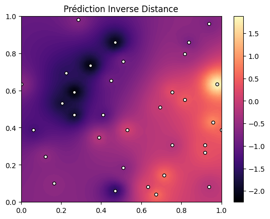

```python
alpha = 2
pred_invdist = np.apply_along_axis(lambda point: inverse_distance(point,alpha, df_obs), 1, df[:,:2]) #appliquer la fonction inverse_distance à chaque point de df
df_invdist = np.column_stack((df[:,:2], pred_invdist))  #créer un tableau avec les coordonnées des points et la valeur prédite
plot_data(df_invdist, df_obs, vmin = min(df[:,2]), vmax = max(df[:,2]), titre = "Prédiction Inverse Distance") #affiche la carte prédite
```

## I.4 Calcul de l'erreur

Afin d'évaluer la performance de chacune des méthodes, il est important de calculer des grandeurs quantitatives. Une grandeur très couramment utilisée est la Root Mean Square Error (RMSE), calculée entre un vecteur de prédiction $\hat{\mathbf{z}} = \left(\hat{z}_j\right)_{j=1}^{n_\text{pred}}$ et les vraies valeurs du phénomène associé $\mathbf{z} = \left(z_j\right)_{j=1}^{n_\text{pred}}.$

On a $$ \mathrm{RMSE}(\mathbf{z},\hat{\mathbf{z}}) = \sqrt{\frac{1}{n_\text{pred}}\sum_{i=1}^{n_\text{pred}} (z_i - \hat{z}_i)^2}. $$

#### Question 7 : Coder la fonction RMSE en complétant le code ci-dessous, et calculer l'erreur pour chacune des 3 prédictions

```python
def RMSE(ypred, ytrue):
    return np.sqrt(1/len(ypred)*np.sum((ypred-ytrue)**2)) #calculer de la RMSE
```

```python
print(RMSE(pred_nn, df[:,2])) #RMSE pour le nearest neighbor
print(RMSE(pred_knn, df[:,2])) #RMSE pour le KNN
print(RMSE(pred_invdist, df[:,2])) #RMSE pour l'inverse distance
```

[output not shown]

## I.5 Tuning des paramètres

#### Question 8 : Calculer et afficher l'évolution de l'erreur lorsque le paramètre $K$ de la méthode des K-voisins varie

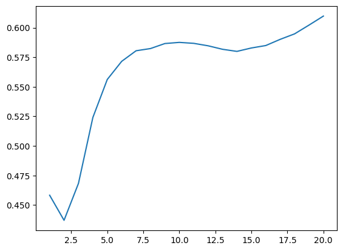

```python
list_rmse_knn = [] # Cette liste va contenir les RMSE pour différents K
for k in range(1,21): #K va aller de 1 à 20
    pred = np.apply_along_axis(lambda point: k_nearest_neighbor(point, k, df_obs), 1, df[:,:2]) # Pour chaque K, calculer la prédiction en chaque point de df
    list_rmse_knn.append(RMSE(pred, df[:,2])) #Calculer la rmse et l'ajouter à la liste
plt.plot(range(1,21), list_rmse_knn) #Afficher l'évolution de la RMSE en fonction de K
```

#### Question 9 : Faire pareil avec le paramètre $\alpha$ de la méthode de la distance inverse

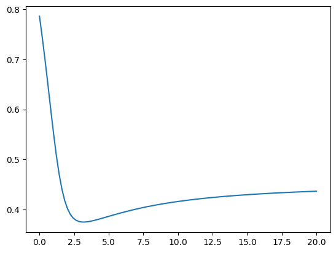

```python
list_rmse_invdist = [] # Cette liste va contenir les RMSE pour différents alpha
for alpha in np.linspace(0,20,100):#alpha va de 0 à 20, et prend 100 valeurs différentes, régulièrement espacées
    pred = np.apply_along_axis(lambda point: inverse_distance(point, alpha, df_obs), 1, df[:,:2]) #pour chaque alpha, calculer la prédiction
    list_rmse_invdist.append(RMSE(pred, df[:,2])) #Calculer la RMSE et l'ajouter à la liste
plt.plot(np.linspace(0,20,100), list_rmse_invdist) # Afficher l'évolution de la RMSE en fonction de alpha
```

#### Question 10 : Effectuer une optimisation plus précise du paramètre $\alpha$ en utilisant la fonction "minimize" du package scipy.optimize.

Documentation: https://docs.scipy.org/doc/scipy/reference/generated/scipy.optimize.minimize.html

```python
def func_rmse_inv(alpha): #On va créer une fonction de alpha que l'on veut minimiser. pour un alpha donné elle calcule la RMSE associée
    pred = np.apply_along_axis(lambda point: inverse_distance(point, alpha,df_obs), 1, df[:,:2]) #On calcule la prédiction pour ce alpha
    return RMSE(pred, df[:,2]) #On renvoie la RMSE associée

res_opt = minimize(func_rmse_inv, 2.5) #On minimise cette fonction, en partant de alpha = 2.5 qui semble être une bonne valeur d'après le plot précédent
```

#### Question 11 : Afficher la carte prédite avec le paramètre $\alpha$ optimale

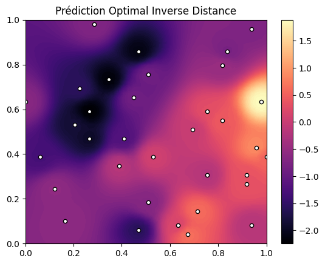

```python
alpha_opt = res_opt["x"][0] #alpha_opt est le meilleur alpha identifié par l'optimisation précédente
pred_invdist_opt = np.apply_along_axis(lambda point: inverse_distance(point, alpha_opt,df_obs), 1, df[:,:2]) # Calculer la prédiction avec cet alpha

df_invdist_opt = np.column_stack((df[:,:2], pred_invdist_opt)) # Créer un tableau avec les points et la valeur prédite
plot_data(df_invdist_opt, df_obs,vmin = min(df[:,2]), vmax = max(df[:,2]), titre = "Prédiction Optimal Inverse Distance") #Afficher la carte prédite
```

# Partie II : Données conductivité

On va maintenant étudier des données de conductivité, mesurées avec un appareil CMD explorer (voir http://gfinstruments.cz/index.php?menu=gi&smenu=iem&cont=cmd_&ear=ov). On va se baser sur les observations contenues dans le tableau "df_obs_conductivity.csv", et on va prédire cette grandeur en tous les points du tableau "data_conductivity.csv". Pour ces 2 tableaux, les 2 premières colonnes correspondent aux coordonnées spatiales, et la 3e à la conductivité.

#### Question 1 : Suivre les mêmes étapes que pour la partie 1, afin notamment d'identifier la meilleur prédiction parmi les méthodes vues en cours

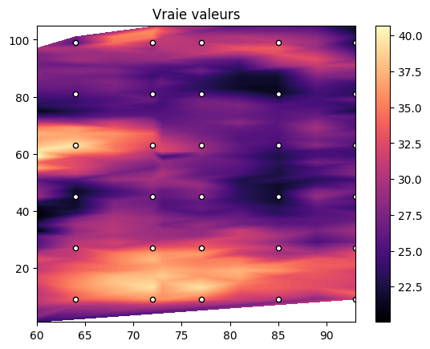

```python
df_condu = pd.read_csv("data/data_conductivity.csv").values  #les données à prédire
df_obs_condu = pd.read_csv("data/df_obs_conductivity.csv").values #les données d'observation
plot_data(df_condu,df_obs = df_obs_condu, titre = "Vraie valeurs") #afficher les données à prédire
```

### Optimisation du paramètre K des K plus proches voisins

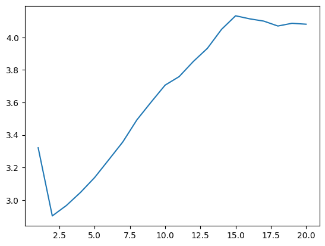

```python
list_rmse_knn = [] # Cette liste va contenir les RMSE pour différents K
for k in range(1,21): #K va aller de 1 à 20
    pred = np.apply_along_axis(lambda point: k_nearest_neighbor(point, k, df_obs_condu), 1, df_condu[:,:2]) #Pour chaque K, calculer la prédiction
    list_rmse_knn.append(RMSE(pred, df_condu[:,2])) #calculer la RMSE associée et l'ajouter à la liste
plt.plot(range(1,21), list_rmse_knn) #l'affiche

k_opt = range(1,21)[np.argmin(list_rmse_knn)]
```

### Optimisation du paramètre $\alpha$ de la distance inverse

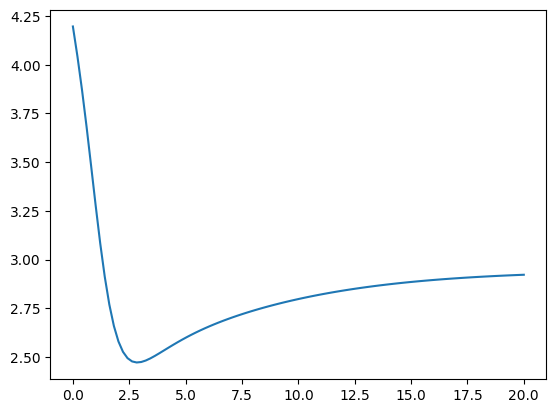

```python
list_rmse_invdist = [] #cette liste va contenir les RMSE calculées pour les différentes valeurs de alpha
for alpha in np.linspace(0,20,100):#alpha va de 0 à 20, et prend 100 valeurs différentes, régulièrement espacées
    pred = np.apply_along_axis(lambda point: inverse_distance(point, alpha, df_obs_condu), 1, df_condu[:,:2]) #pour chaque alpha, calculer la prédiction
    list_rmse_invdist.append(RMSE(pred, df_condu[:,2])) #calculer la RMSE et l'ajouter à la liste
plt.plot(np.linspace(0,20,100), list_rmse_invdist) #afficher l'évolution de la RMSE en fonction de alpha
```

On voit que la RMSE obtenue avec la méthodes de la distance inverse est plus faible que celle obtenue avec les KNN, c'est la meilleure méthode ici par rapport à ce critère, on va se concentrer dessus

```python
def func_rmse_inv(alpha): #cette fonction de alpha va être optimisée. Pour un alpha donné, elle renvoie la RMSE associée
    pred = np.apply_along_axis(lambda point: inverse_distance(point,alpha,df_obs_condu), 1, df_condu[:,:2]) #calcul de la prédiction
    return RMSE(pred, df_condu[:,2]) #on renvoie la RMSE associée

res_opt_condu = minimize(func_rmse_inv, 2.5)
```

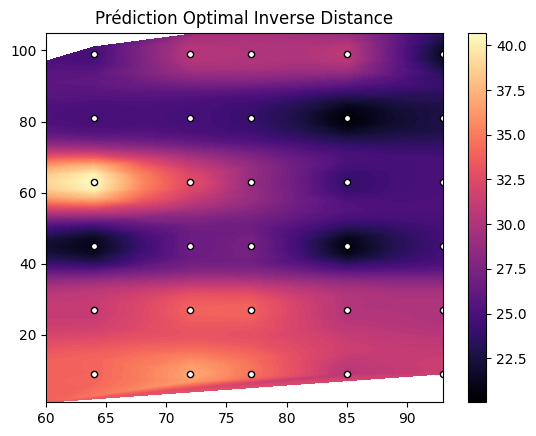

```python
alpha_opt_condu = res_opt_condu["x"][0] # le meilleur alpha identifié par l'optimisation
pred_invdist_opt = np.apply_along_axis(lambda point: inverse_distance(point, alpha_opt_condu, df_obs_condu), 1, df_condu[:,:2]) #on calcule la prédiction optimale pour cet alpha

df_invdist_opt = np.column_stack((df_condu[:,:2], pred_invdist_opt)) #On crée un tableau avec les points de prédiction et la valeur prédite
plot_data(df_invdist_opt, df_obs_condu, vmin = min(df_condu[:,2]), vmax = max(df_condu[:,2]), titre = "Prédiction Optimal Inverse Distance") #On affiche la prédiction
```

# Partie III : Données de température

On va ici étudier des données de température dans une région donnée du monde. Comme précédemment, on va se baser sur des observations, stockées dans la base de données "df_obs_temperature.csv". La prédiction doit s'effectuer en les points du domaine stockées dans le tableau "df_temperature.csv". Pour ces 2 tableaux, les 2 premières colonnes correspondent respectivement à la longitude et la latitude, et la troisième correspond à la température. Pour information, ces données ont été mesurée le 01/02/2025.

Il est important de noter que la notion de distance n'est pas triviale sur une sphère comme la surface de la Terre. On ne rentre pas dans les détails théoriques ici, et on va considérer la distance "à vol d'oiseau" sur la sphère, aussi appelée distance orthodromique. Cette distance est calculée par la fonction "distance_earth" ci-dessous, qui prend en argument 2 points définit par leur longitude et latitude.

Pour étudier le lien entre les température en un point A et un point B, on a également un autre tableau "df_temperature_3points.csv", qui contient les données de température du mois de février 2025 pour 3 points, appelés A, B et C. Le tableau contient 5 colonnes : longitude, latitude, la date, la température, et une colonne "point" qui indique si il s'agit du point A,B ou C.

### Distance sur la terre

Comme expliqué plus haut, la fonction distance_earth calcule la distance entre 2 points à partir de leurs coordonnées (longitude, latitude). La fonction dist_point_obs_earth calcule prend en argument un point x défini par ses coordonnées (longitude, latitude), et un tableau "df_obs" contenant les points d'observations, et retourne un vecteur contenant les distances prenant en compte la surface de la terre entre le point x et chaque point de df_obs,

```python
def distance_earth(point1, point2): # Cette distance prend en argument 2 points définis par leur couple (longitude, latitude) et renvoie la distance
    R = 6371.0  #rayon de la terre
    lat1, lon1, lat2, lon2 = map(np.radians, [point1[1], point1[0], point2[1], point2[0]]) #conversion en radian
    dlat = lat2 - lat1 #écart de latitude
    dlon = lon2 - lon1 #écart de longitude
    a = np.sin(dlat / 2)**2 + np.cos(lat1) * np.cos(lat2) * np.sin(dlon / 2)**2
    c = 2 * np.arcsin(np.sqrt(a))
    return R * c

def dist_point_obs_earth(x, df_obs): #distances entre un point x et chaque point de df_obs
    dists = np.apply_along_axis(lambda vec: distance_earth(x, vec), axis=1, arr=df_obs)
    return(dists)
```

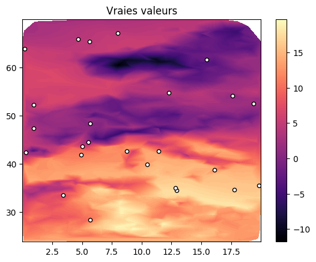

```python
df_temp = pd.read_csv("data/df_temperature.csv").values #données à prédire
df_obs_temp = pd.read_csv("data/df_obs_temperature.csv").values #données d'observations
df_3points = pd.read_csv("data/df_temperature_3points.csv") # 3 points A,B et C pour lesquels on a des données de température au cours du mois de février

plot_data(df_temp,df_obs = df_obs_temp, titre = "Vraies valeurs") #Visualisation des données à prédire
```

### Visualisation géographique

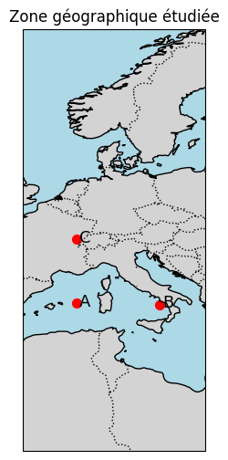

```python
points = df_3points[["longitude","latitude","point"]].drop_duplicates() #Base de données avec seulement les coordonnées des points A,B et C et leur label

fig = plt.figure(figsize=(10, 6))
ax = plt.axes(projection=ccrs.PlateCarree())

# Fond de carte
ax.add_feature(cfeature.LAND, facecolor="lightgray")
ax.add_feature(cfeature.OCEAN, facecolor="lightblue")
ax.add_feature(cfeature.BORDERS, linestyle=':')
ax.add_feature(cfeature.COASTLINE)

# Tracer les points
ax.scatter(points["longitude"], points["latitude"], color='red', s=50, transform=ccrs.PlateCarree())

# Ajouter les labels A, B et C
for i, row in points.iterrows():
    ax.text(row["longitude"] + 0.3, row["latitude"] -0.3, row["point"],
            transform=ccrs.PlateCarree(), fontsize=13)

# Ajuster la vue
ax.set_extent([
    df_temp[:,0].min() ,
    df_temp[:,0].max() ,
    df_temp[:,1].min() ,
    df_temp[:,1].max() ,
], crs=ccrs.PlateCarree())


ax.set_title("Zone géographique étudiée")
plt.show()
```

## III.1 Etude des données en A,B et C

```python
coordA = points.values[0,:2] #coordonnées du point A
coordB = points.values[1,:2] #coordonnées du point B
coordC = points.values[2,:2] #coordonnées du point C

print(distance_earth(coordA,coordB)) #distance entre A et B
print(distance_earth(coordA,coordC)) #distance entre A et C
```

```
780.707427952963
781.6528261763235
```

## Calcul de covariance et corrélation

#### Définitions

- La **variance** d'une variable aléatoire réelle nous donne l'espérance de l'écart quadratique à la moyenne :

$$\mathbb{V}(X) = \mathbb{E}\left((X-\mathbb{E}(X))^2\right)$$

- Si $X$ et $Y$ sont de carré intégrable (i.e. leur variance est définie), la **covariance** entre $X$ et $Y$ est définie et permet de mesurer comment les 2 v.a. évoluent ensemble : $$\text{cov}(X,Y) = \mathbb{E}\left((X-\mathbb{E}(X))(Y-\mathbb{E}(Y))\right)$$
- **Le coefficient de corrélation** est une covariance normalisée, définie quand $\mathbb{V}(X)>0$ et $\mathbb{V}(Y)>0,$ par $$\rho(X,Y) = \frac{\text{cov}(X,Y)}{\sqrt{\mathbb{V}(X)\mathbb{V}(Y)}}$$

#### Estimation de ces grandeurs

On considère 2 variables aléatoires $(X,Y)$, $(X_1,Y_1), \dots, (X_n,Y_n)$ n couples aléatoires indépendants et suivant la même distribution que $(X,Y)$.

- Un estimateur de la variance de $X$ est alors $$S_n = \frac{1}{n-1} \sum_{i=1}^{n} (X_i - M_n)^2 \text{ avec }M_n = \frac{1}{n}\sum_{i=1}^{n} X_i$$
- Un estimateur de la covariance entre $X$ et $Y$ est $$C_n = \frac{1}{n-1} \sum_{i=1}^{n} (X_i - M_n)(Y_i- \tilde{M}_n) \text{ avec }M_n = \frac{1}{n}\sum_{i=1}^{n} X_i \text{ et } \tilde{M}_n = \frac{1}{n}\sum_{i=1}^{n} Y_i$$

#### Question 2 : Visualiser la température en A en fonction de la température en B, puis la température en A en fonction de la température en C. Commenter.

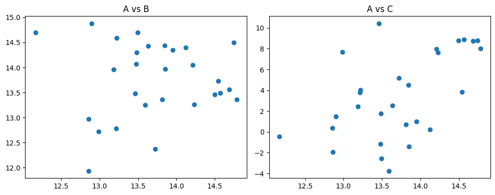

```python
vecA = df_3points[df_3points["point"] == "A"]["t"].values #Données de température en février pour le point A
vecB = df_3points[df_3points["point"] == "B"]["t"].values #Données de température en février pour le point B
vecC = df_3points[df_3points["point"] == "C"]["t"].values #Données de température en février pour le point C


fig, axes = plt.subplots(1, 2, figsize=(10, 4))  # 1 ligne, 2 colonnes pour avoir les plots côte à côte
axes[0].scatter(vecA, vecB) # A en fonction de B
axes[0].set_title("A vs B")
axes[1].scatter(vecA, vecC) # A en fonction de C
axes[1].set_title("A vs C")
plt.tight_layout()
plt.show()
```

La valeurs entre A et C semblent plus corrélées que celles entre A et B. Confirmons maintenant cela pour le calcul.

#### Question 3 : Coder une fonction qui permet 2 calculer la corrélation empirique entre 2 vecteurs

```python
def func_correlation(v1,v2): # corrélation entre 2 vecteurs v1 et v2
    mean1 = np.mean(v1) #moyenne empirique de v1
    mean2 = np.mean(v2) #moyenne empirique de v2
    var1 = 1/(len(v1)-1)*np.sum((v1-mean1)**2) #variance empirique de v1
    var2 = 1/(len(v2)-1)*np.sum((v2-mean2)**2) #variance empirique de v2
    vec = (v1-mean1)*(v2-mean2)
    covar = 1/(len(vec)-1)*np.sum(vec) #covariance empirique entre v1 et v2
    return(covar/np.sqrt(var1*var2)) #renvoyer la corrélation
```

#### Question 4 : Calculer la corrélation entre les températures en A et en B d'une part, et en A et C d'autre part. Commenter

```python
print(func_correlation(vecA,vecB)) #correlation entre A et B
print(func_correlation(vecA,vecC)) #correlation entre A et C
```

```
0.02009909064348867
0.539567031309314
```

Evidemment, ici l'étude se focalise seulement sur 3 points pour simplifier, et il faudrait considérer l'ensemble des dépendances pour confirmer l'hypothèse. L'idée ici est simplement de sentir que l'étude des la dépendances entre les données est importante, et des méthodes avancées seront présentées dans la suite du cours.

## III.2 Prediction par distance inverse classique

Cette analyse va nous aider à peut-être améliorer la prédiction. Revenons tout d'abord au cas classique : on a nos observations dans un tableau, et on veut faire de la prédiction dans tout le domaine par distance inverse.

#### Question 5 : Modifier la fonction inverse_distance précédemment créée avec la distance adaptée au cas de la sphère

```python
def inverse_distance_earth(x0,df_obs,alpha = 1): #On modifier simplement la distance utilisée pour la fonction inverse_distance
    dists = dist_point_obs_earth(x0, df_obs) #Distances entre x0 et les points d'observation, en utilisant la distance adaptée à la sphère
    if min(dists) < 10**(-5): return(df_obs[np.argmin(dists),2]) #Si la distance minimum est très petite, retourner la valeur du plus proche voisin pour éviter les divisions par ~ 0
    else:
        weights = 1/dists**alpha #Calculer la pondération de chaque observation, qui est l'inverse de la distance à la puissance alpha
        return(sum(weights*df_obs[:,2])/sum(weights)) #renvoyer la moyenne des observations pondérées par les poids précédemment calculés
```

#### Question 6 : Regarder l'évolution de l'erreur de prédiction en fonction de $\alpha$

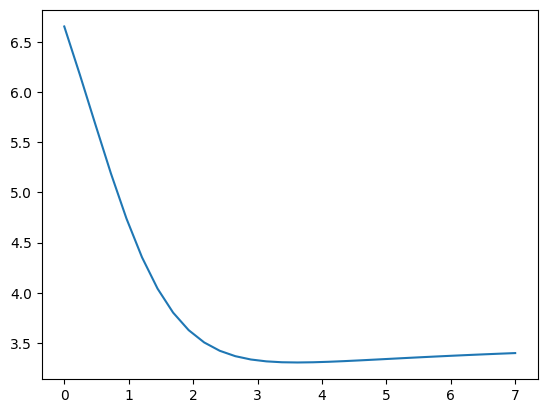

```python
def func_rmse_inv(alpha): #Fonction qui calcule en fonction de alpha la RMSE
    pred = np.apply_along_axis(lambda point: inverse_distance_earth(point,df_obs_temp,alpha), 1, df_temp[:,:2]) #Pour un alpha donné on calcule la prédiction
    return RMSE(pred, df_temp[:,2]) #Puis on renvoie la RMSE associée


list_rmse_invdist = [func_rmse_inv(alpha) for alpha in np.linspace(0,7,30)] #Calculer la RMSE pour 0 <= alpha <= 7, pour 30 valeurs de alpha différentes
plt.plot(np.linspace(0,7,30), list_rmse_invdist) #afficher l'évolution de la RMSE en fonction de alpha
```

#### Question 7 : Trouver le $\alpha$ optimal grâce à la fonction minimize, et afficher la carte prédite associée

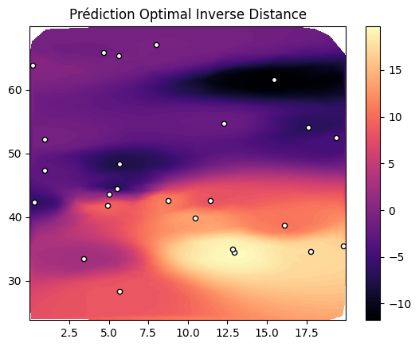

```python
res_opt = minimize(func_rmse_inv, 3) #Minimiser la fonction proprement, en partant de alpha = 3 qui semble être une bonne valeur

alpha_opt = res_opt["x"][0] #Meilleur alpha identifié

RMSE_standard = res_opt["fun"] # On stocke ici la RMSE obtenue (pour comparaison ultérieure)

pred_invdist_opt = np.apply_along_axis(lambda point: inverse_distance_earth(point,df_obs_temp,alpha_opt), 1, df_temp[:,:2]) # Calculer la prédiction associé à ce meilleur alpha

df_invdist_opt = np.column_stack((df_temp[:,:2], pred_invdist_opt)) # Stocker les résultats dans un tableau avec les points et la prédiction
plot_data(df_invdist_opt, df_obs_temp, vmin = min(df_temp[:,2]), vmax = max(df_temp[:,2]),titre = "Prédiction Optimal Inverse Distance") #Afficher la prédiction
```

## III.3 Amélioration de la prédiction

#### Question 8 : Au regard des observations faites dans la partie III.1 sur les points A, B et C, proposer une modification de la distance prise en compte dans la fonction "inverse_distance" afin d'améliorer la prédiction. Si cette fonction fait intervenir un paramètre, l'optimiser. Conserver le $\alpha$ optimal calculé précédemment pour votre fonction inverse_distance améliorée.

Au regard de l'analyse précedente, on va introduire une nouvelle distance entre 2 points $\mathbf{x} = (x_1,x_2)$ et $\mathbf{y} = (y_1,y_2)$ où les coordonnées sont la latitude et la longitude du point. On définit ainsi $$d(\mathbf{x},\mathbf{y}) = \sqrt{\lvert x_1 - x_2\rvert^2 + \omega\lvert y_1 - y_2\rvert^2}$$

Un paramètre $\omega \geq 0$ est ainsi introduit pour pondérer l'importance de l'écart entre les latitudes:

- Si $\omega$ est très grand, alors seul l'écart entre les latitudes va compter dans le calcul de la distance
- Si $\omega$ est très proche de $0$, alors seul l'écart entre les longitudes aura de l'importance

```python
def dist_point_bis(x, df_obs, w = 1): #nouveau calcul des entre un point et l'ensemble des observations, en prenant en compte le parametre omega
    dists = np.sqrt((df_obs[:, 0] - x[0])**2 + w * (df_obs[:, 1] - x[1])**2)
    return(dists)

def inverse_distance_bis(x0,alpha, df_obs, w = 1): #La nouvelle fonction inverse_distance, qui prend simplement en compte ce nouvelle distance
    dists = dist_point_bis(x0, df_obs,w = w)
    if min(dists) < 10**(-5): return(df_obs[np.argmin(dists),2])
    else:
        weights = 1/dists**alpha
        return(sum(weights*df_obs[:,2])/sum(weights))
```

Il est important de noter qu'une optimisation complète rechercherait le couple optimal $(\alpha, \omega)$, pas de manière séquentielle comme on vient de le faire.

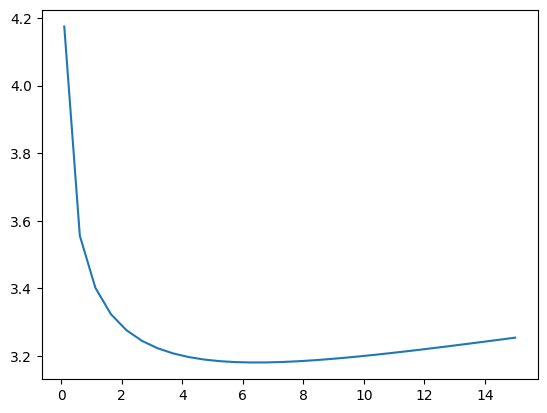

```python
def func_rmse_bis(w): #On va vouloir optimiser cette fonction de omega, qui pour chaque omega donne la RMSE associée
    pred = np.apply_along_axis(lambda point: inverse_distance_bis(point, alpha_opt, df_obs_temp, w = w), 1, df_temp[:,:2]) #on calcule la prédiction
    return RMSE(pred, df_temp[:,2]) #on renvoie la RMSE

list_rmse_bis = [func_rmse_bis(w) for w in np.linspace(0.1,15,30)] #On calcule la RMSE pour différents omega entre 0.1 et 15, régulièrement espacées
plt.plot(np.linspace(0.1,15,30), list_rmse_bis) #on affiche l'évolution de la RMSE avec omega

res_opt_bis = minimize(func_rmse_bis, 2) #On minimise rigourement la fonction pour obtenir le omega optimal
weight_opt = res_opt_bis["x"][0] #Le omega optimal obtenu
RMSE_bis = res_opt_bis["fun"] # La RMSE optimal obtenue
```

#### Question 9 : Afficher la prédiction obtenue avec cette nouvelle distance optimisée et calculer la RMSE associée. Comparer le gain relatif par rapport à la RMSE précédente.

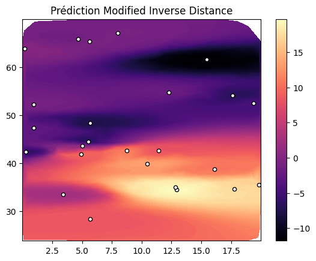

```python
pred_invdist_bis = np.apply_along_axis(lambda point: inverse_distance_bis(point,alpha_opt,df_obs_temp, w = weight_opt), 1, df_temp[:,:2]) #On calcule la prédiction avec le coefficient omega optimal

df_invdist_bis = np.column_stack((df_temp[:,:2], pred_invdist_bis)) # On stocke les données dans un tableau
plot_data(df_invdist_bis, df_obs_temp, vmin = min(df_temp[:,2]), vmax = max(df_temp[:,2]), titre = "Prédiction Modified Inverse Distance") #On affiche la prédiction
```

```python
gain_relatif = -(RMSE_bis-RMSE_standard)/RMSE_standard #Ecart relatif entre la RMSE obtenue initialement et la RMSE obtenue avec notre nouvelle distance
print(gain_relatif)
```

```
0.03745038234940741
```